# INN Hotels Project

## Context

A significant number of hotel bookings are called-off due to cancellations or no-shows. The typical reasons for cancellations include change of plans, scheduling conflicts, etc. This is often made easier by the option to do so free of charge or preferably at a low cost which is beneficial to hotel guests but it is a less desirable and possibly revenue-diminishing factor for hotels to deal with. Such losses are particularly high on last-minute cancellations.

The new technologies involving online booking channels have dramatically changed customers’ booking possibilities and behavior. This adds a further dimension to the challenge of how hotels handle cancellations, which are no longer limited to traditional booking and guest characteristics.

The cancellation of bookings impact a hotel on various fronts:

- Loss of resources (revenue) when the hotel cannot resell the room.
- Additional costs of distribution channels by increasing commissions or paying for publicity to help sell these rooms.
- Lowering prices last minute, so the hotel can resell a room, resulting in reducing the profit margin.
- Human resources to make arrangements for the guests.

## Objective

The increasing number of cancellations calls for a Machine Learning based solution that can help in predicting which booking is likely to be canceled. INN Hotels Group has a chain of hotels in Portugal, they are facing problems with the high number of booking cancellations and have reached out to your firm for data-driven solutions. You as a data scientist have to analyze the data provided to find which factors have a high influence on booking cancellations, build a predictive model that can predict which booking is going to be canceled in advance, and help in formulating profitable policies for cancellations and refunds.

## Data Description

The data contains the different attributes of customers' booking details. The detailed data dictionary is given below.

**Data Dictionary**

- Booking_ID: unique identifier of each booking
- no_of_adults: Number of adults
- no_of_children: Number of Children
- no_of_weekend_nights: Number of weekend nights (Saturday or Sunday) the guest stayed or booked to stay at the hotel
- no_of_week_nights: Number of week nights (Monday to Friday) the guest stayed or booked to stay at the hotel
- type_of_meal_plan: Type of meal plan booked by the customer:
  - Not Selected – No meal plan selected
  - Meal Plan 1 – Breakfast
  - Meal Plan 2 – Half board (breakfast and one other meal)
  - Meal Plan 3 – Full board (breakfast, lunch, and dinner)
- required_car_parking_space: Does the customer require a car parking space? (0 - No, 1- Yes)
- room_type_reserved: Type of room reserved by the customer. The values are ciphered (encoded) by INN Hotels.
- lead_time: Number of days between the date of booking and the arrival date
- arrival_year: Year of arrival date
- arrival_month: Month of arrival date
- arrival_date: Date of the month
- market_segment_type: Market segment designation.
- repeated_guest: Is the customer a repeated guest? (0 - No, 1- Yes)
- no_of_previous_cancellations: Number of previous bookings that were canceled by the customer prior to the current booking
- no_of_previous_bookings_not_canceled: Number of previous bookings not canceled by the customer prior to the current booking
- avg_price_per_room: Average price per day of the reservation; prices of the rooms are dynamic. (in euros)
- no_of_special_requests: Total number of special requests made by the customer (e.g. high floor, view from the room, etc)
- booking_status: Flag indicating if the booking was canceled or not.

## Importing necessary libraries and data

```python
# this will help in making the Python code more structured automatically (help adhere to good coding practices)
#%load_ext nb_black

import warnings

warnings.filterwarnings("ignore")
from statsmodels.tools.sm_exceptions import ConvergenceWarning

warnings.simplefilter("ignore", ConvergenceWarning)

# Libraries to help with reading and manipulating data
import pandas as pd
import numpy as np

# libaries to help with data visualization
import matplotlib.pyplot as plt
import seaborn as sns

# Removes the limit for the number of displayed columns
pd.set_option("display.max_columns", None)
# Sets the limit for the number of displayed rows
pd.set_option("display.max_rows", 200)
# setting the precision of floating numbers to 5 decimal points
pd.set_option("display.float_format", lambda x: "%.5f" % x)

# Library to split data
from sklearn.model_selection import train_test_split

# To build model for prediction
import statsmodels.stats.api as sms
from statsmodels.stats.outliers_influence import variance_inflation_factor
import statsmodels.api as sm
from statsmodels.tools.tools import add_constant
from sklearn.tree import DecisionTreeClassifier
from sklearn import tree

# To tune different models
from sklearn.model_selection import GridSearchCV


# To get diferent metric scores
from sklearn.metrics import (
    f1_score,
    accuracy_score,
    recall_score,
    precision_score,
    confusion_matrix,
    roc_auc_score,
    plot_confusion_matrix,
    precision_recall_curve,
    roc_curve,
    make_scorer,
)

# importing data
hotel = pd.read_csv('INNHotelsGroup.csv')
```

## Data Overview

- Observations
- Sanity checks

```python
# checking top 5 rows of data
hotel.head()
```

|  | Booking_ID | no_of_adults | no_of_children | no_of_weekend_nights | no_of_week_nights | type_of_meal_plan | required_car_parking_space | room_type_reserved | lead_time | arrival_year | arrival_month | arrival_date | market_segment_type | repeated_guest | no_of_previous_cancellations | no_of_previous_bookings_not_canceled | avg_price_per_room | no_of_special_requests | booking_status |
| --- | --- | --- | --- | --- | --- | --- | --- | --- | --- | --- | --- | --- | --- | --- | --- | --- | --- | --- | --- |
| 0 | INN00001 | 2 | 0 | 1 | 2 | Meal Plan 1 | 0 | Room_Type 1 | 224 | 2017 | 10 | 2 | Offline | 0 | 0 | 0 | 65.00000 | 0 | Not_Canceled |
| 1 | INN00002 | 2 | 0 | 2 | 3 | Not Selected | 0 | Room_Type 1 | 5 | 2018 | 11 | 6 | Online | 0 | 0 | 0 | 106.68000 | 1 | Not_Canceled |
| 2 | INN00003 | 1 | 0 | 2 | 1 | Meal Plan 1 | 0 | Room_Type 1 | 1 | 2018 | 2 | 28 | Online | 0 | 0 | 0 | 60.00000 | 0 | Canceled |
| 3 | INN00004 | 2 | 0 | 0 | 2 | Meal Plan 1 | 0 | Room_Type 1 | 211 | 2018 | 5 | 20 | Online | 0 | 0 | 0 | 100.00000 | 0 | Canceled |
| 4 | INN00005 | 2 | 0 | 1 | 1 | Not Selected | 0 | Room_Type 1 | 48 | 2018 | 4 | 11 | Online | 0 | 0 | 0 | 94.50000 | 0 | Canceled |

```python
# checking bottom 5 rows of data
hotel.tail()
```

|  | Booking_ID | no_of_adults | no_of_children | no_of_weekend_nights | no_of_week_nights | type_of_meal_plan | required_car_parking_space | room_type_reserved | lead_time | arrival_year | arrival_month | arrival_date | market_segment_type | repeated_guest | no_of_previous_cancellations | no_of_previous_bookings_not_canceled | avg_price_per_room | no_of_special_requests | booking_status |
| --- | --- | --- | --- | --- | --- | --- | --- | --- | --- | --- | --- | --- | --- | --- | --- | --- | --- | --- | --- |
| 36270 | INN36271 | 3 | 0 | 2 | 6 | Meal Plan 1 | 0 | Room_Type 4 | 85 | 2018 | 8 | 3 | Online | 0 | 0 | 0 | 167.80000 | 1 | Not_Canceled |
| 36271 | INN36272 | 2 | 0 | 1 | 3 | Meal Plan 1 | 0 | Room_Type 1 | 228 | 2018 | 10 | 17 | Online | 0 | 0 | 0 | 90.95000 | 2 | Canceled |
| 36272 | INN36273 | 2 | 0 | 2 | 6 | Meal Plan 1 | 0 | Room_Type 1 | 148 | 2018 | 7 | 1 | Online | 0 | 0 | 0 | 98.39000 | 2 | Not_Canceled |
| 36273 | INN36274 | 2 | 0 | 0 | 3 | Not Selected | 0 | Room_Type 1 | 63 | 2018 | 4 | 21 | Online | 0 | 0 | 0 | 94.50000 | 0 | Canceled |
| 36274 | INN36275 | 2 | 0 | 1 | 2 | Meal Plan 1 | 0 | Room_Type 1 | 207 | 2018 | 12 | 30 | Offline | 0 | 0 | 0 | 161.67000 | 0 | Not_Canceled |

```python
# checking shape of data
print(f'There are {hotel.shape[0]} rows and {hotel.shape[1]} columns in the data.')
```

```
There are 36275 rows and 19 columns in the data.
```

```python
# checking data types
hotel.info()
```

```
<class 'pandas.core.frame.DataFrame'>
RangeIndex: 36275 entries, 0 to 36274
Data columns (total 19 columns):
 #   Column                                Non-Null Count  Dtype
---  ------                                --------------  -----
 0   Booking_ID                            36275 non-null  object
 1   no_of_adults                          36275 non-null  int64
 2   no_of_children                        36275 non-null  int64
 3   no_of_weekend_nights                  36275 non-null  int64
 4   no_of_week_nights                     36275 non-null  int64
 5   type_of_meal_plan                     36275 non-null  object
 6   required_car_parking_space            36275 non-null  int64
 7   room_type_reserved                    36275 non-null  object
 8   lead_time                             36275 non-null  int64
 9   arrival_year                          36275 non-null  int64
 10  arrival_month                         36275 non-null  int64
 11  arrival_date                          36275 non-null  int64
 12  market_segment_type                   36275 non-null  object
 13  repeated_guest                        36275 non-null  int64
 14  no_of_previous_cancellations          36275 non-null  int64
 15  no_of_previous_bookings_not_canceled  36275 non-null  int64
 16  avg_price_per_room                    36275 non-null  float64
 17  no_of_special_requests                36275 non-null  int64
 18  booking_status                        36275 non-null  object
dtypes: float64(1), int64(13), object(5)
memory usage: 5.3+ MB
```

```python
# checking for duplicates in the data
print(f'There are {hotel.duplicated().sum()} duplicates in the data.')
```

```
There are 0 duplicates in the data.
```

```python
# since booking ID column will not be useful to our machine learning models, we can drop it
hotel = hotel.drop('Booking_ID', axis=1)
```

```python
# checking top 5 rows again with booking ID dropped from data
hotel.head()
```

|  | no_of_adults | no_of_children | no_of_weekend_nights | no_of_week_nights | type_of_meal_plan | required_car_parking_space | room_type_reserved | lead_time | arrival_year | arrival_month | arrival_date | market_segment_type | repeated_guest | no_of_previous_cancellations | no_of_previous_bookings_not_canceled | avg_price_per_room | no_of_special_requests | booking_status |
| --- | --- | --- | --- | --- | --- | --- | --- | --- | --- | --- | --- | --- | --- | --- | --- | --- | --- | --- |
| 0 | 2 | 0 | 1 | 2 | Meal Plan 1 | 0 | Room_Type 1 | 224 | 2017 | 10 | 2 | Offline | 0 | 0 | 0 | 65.00000 | 0 | Not_Canceled |
| 1 | 2 | 0 | 2 | 3 | Not Selected | 0 | Room_Type 1 | 5 | 2018 | 11 | 6 | Online | 0 | 0 | 0 | 106.68000 | 1 | Not_Canceled |
| 2 | 1 | 0 | 2 | 1 | Meal Plan 1 | 0 | Room_Type 1 | 1 | 2018 | 2 | 28 | Online | 0 | 0 | 0 | 60.00000 | 0 | Canceled |
| 3 | 2 | 0 | 0 | 2 | Meal Plan 1 | 0 | Room_Type 1 | 211 | 2018 | 5 | 20 | Online | 0 | 0 | 0 | 100.00000 | 0 | Canceled |
| 4 | 2 | 0 | 1 | 1 | Not Selected | 0 | Room_Type 1 | 48 | 2018 | 4 | 11 | Online | 0 | 0 | 0 | 94.50000 | 0 | Canceled |

```python
# checking data types again with booking ID dropped
hotel.info()
```

```
<class 'pandas.core.frame.DataFrame'>
RangeIndex: 36275 entries, 0 to 36274
Data columns (total 18 columns):
 #   Column                                Non-Null Count  Dtype
---  ------                                --------------  -----
 0   no_of_adults                          36275 non-null  int64
 1   no_of_children                        36275 non-null  int64
 2   no_of_weekend_nights                  36275 non-null  int64
 3   no_of_week_nights                     36275 non-null  int64
 4   type_of_meal_plan                     36275 non-null  object
 5   required_car_parking_space            36275 non-null  int64
 6   room_type_reserved                    36275 non-null  object
 7   lead_time                             36275 non-null  int64
 8   arrival_year                          36275 non-null  int64
 9   arrival_month                         36275 non-null  int64
 10  arrival_date                          36275 non-null  int64
 11  market_segment_type                   36275 non-null  object
 12  repeated_guest                        36275 non-null  int64
 13  no_of_previous_cancellations          36275 non-null  int64
 14  no_of_previous_bookings_not_canceled  36275 non-null  int64
 15  avg_price_per_room                    36275 non-null  float64
 16  no_of_special_requests                36275 non-null  int64
 17  booking_status                        36275 non-null  object
dtypes: float64(1), int64(13), object(4)
memory usage: 5.0+ MB
```

```python
# statistical summary of data
hotel.describe().T
```

|  | count | mean | std | min | 25% | 50% | 75% | max |
| --- | --- | --- | --- | --- | --- | --- | --- | --- |
| no_of_adults | 36275.00000 | 1.84496 | 0.51871 | 0.00000 | 2.00000 | 2.00000 | 2.00000 | 4.00000 |
| no_of_children | 36275.00000 | 0.10528 | 0.40265 | 0.00000 | 0.00000 | 0.00000 | 0.00000 | 10.00000 |
| no_of_weekend_nights | 36275.00000 | 0.81072 | 0.87064 | 0.00000 | 0.00000 | 1.00000 | 2.00000 | 7.00000 |
| no_of_week_nights | 36275.00000 | 2.20430 | 1.41090 | 0.00000 | 1.00000 | 2.00000 | 3.00000 | 17.00000 |
| required_car_parking_space | 36275.00000 | 0.03099 | 0.17328 | 0.00000 | 0.00000 | 0.00000 | 0.00000 | 1.00000 |
| lead_time | 36275.00000 | 85.23256 | 85.93082 | 0.00000 | 17.00000 | 57.00000 | 126.00000 | 443.00000 |
| arrival_year | 36275.00000 | 2017.82043 | 0.38384 | 2017.00000 | 2018.00000 | 2018.00000 | 2018.00000 | 2018.00000 |
| arrival_month | 36275.00000 | 7.42365 | 3.06989 | 1.00000 | 5.00000 | 8.00000 | 10.00000 | 12.00000 |
| arrival_date | 36275.00000 | 15.59700 | 8.74045 | 1.00000 | 8.00000 | 16.00000 | 23.00000 | 31.00000 |
| repeated_guest | 36275.00000 | 0.02564 | 0.15805 | 0.00000 | 0.00000 | 0.00000 | 0.00000 | 1.00000 |
| no_of_previous_cancellations | 36275.00000 | 0.02335 | 0.36833 | 0.00000 | 0.00000 | 0.00000 | 0.00000 | 13.00000 |
| no_of_previous_bookings_not_canceled | 36275.00000 | 0.15341 | 1.75417 | 0.00000 | 0.00000 | 0.00000 | 0.00000 | 58.00000 |
| avg_price_per_room | 36275.00000 | 103.42354 | 35.08942 | 0.00000 | 80.30000 | 99.45000 | 120.00000 | 540.00000 |
| no_of_special_requests | 36275.00000 | 0.61966 | 0.78624 | 0.00000 | 0.00000 | 0.00000 | 1.00000 | 5.00000 |

#### Observations:

- Since booking ID does not have much value to the models that we will be creating, the column was dropped from the dataset.
- There are 3 datatypes in the dataset.
  - 1 float64
  - 13 int64
  - 4 object
- There are no duplicate, null, or missing values in the dataset.
- The dataset is made up of 36275 rows and 18 columns (originally 19 but we dropped booking ID).

## Exploratory Data Analysis (EDA)

- EDA is an important part of any project involving data.
- It is important to investigate and understand the data better before building a model with it.
- A few questions have been mentioned below which will help you approach the analysis in the right manner and generate insights from the data.
- A thorough analysis of the data, in addition to the questions mentioned below, should be done.

```python
# following functions taken from MLS2 - Session_Notebook_Machine_Failure_Prediction.ipynb


def histogram_boxplot(data, feature, figsize=(15, 10), kde=False, bins=None):
    """
    Boxplot and histogram combined

    data: dataframe
    feature: dataframe column
    figsize: size of figure (default (15,10))
    kde: whether to show the density curve (default False)
    bins: number of bins for histogram (default None)
    """
    f2, (ax_box2, ax_hist2) = plt.subplots(
        nrows=2,  # Number of rows of the subplot grid= 2
        sharex=True,  # x-axis will be shared among all subplots
        gridspec_kw={"height_ratios": (0.25, 0.75)},
        figsize=figsize,
    )  # creating the 2 subplots
    sns.boxplot(
        data=data, x=feature, ax=ax_box2, showmeans=True, color="violet"
    )  # boxplot will be created and a triangle will indicate the mean value of the column
    sns.histplot(
        data=data, x=feature, kde=kde, ax=ax_hist2, bins=bins
    ) if bins else sns.histplot(
        data=data, x=feature, kde=kde, ax=ax_hist2
    )  # For histogram
    ax_hist2.axvline(
        data[feature].mean(), color="green", linestyle="--"
    )  # Add mean to the histogram
    ax_hist2.axvline(
        data[feature].median(), color="black", linestyle="-"
    )  # Add median to the histogram

# function to create labeled barplots


def labeled_barplot(data, feature, perc=False, n=None):
    """
    Barplot with percentage at the top

    data: dataframe
    feature: dataframe column
    perc: whether to display percentages instead of count (default is False)
    n: displays the top n category levels (default is None, i.e., display all levels)
    """

    total = len(data[feature])  # length of the column
    count = data[feature].nunique()
    if n is None:
        plt.figure(figsize=(count + 2, 6))
    else:
        plt.figure(figsize=(n + 2, 6))

    plt.xticks(rotation=90, fontsize=15)
    ax = sns.countplot(
        data=data,
        x=feature,
        palette="Paired",
        order=data[feature].value_counts().index[:n],
    )

    for p in ax.patches:
        if perc == True:
            label = "{:.1f}%".format(
                100 * p.get_height() / total
            )  # percentage of each class of the category
        else:
            label = p.get_height()  # count of each level of the category

        x = p.get_x() + p.get_width() / 2  # width of the plot
        y = p.get_height()  # height of the plot

        ax.annotate(
            label,
            (x, y),
            ha="center",
            va="center",
            size=12,
            xytext=(0, 5),
            textcoords="offset points",
        )  # annotate the percentage

    plt.show()  # show the plot

def stacked_barplot(data, predictor, target):
    """
    Print the category counts and plot a stacked bar chart

    data: dataframe
    predictor: independent variable
    target: target variable
    """
    count = data[predictor].nunique()
    sorter = data[target].value_counts().index[-1]
    tab1 = pd.crosstab(data[predictor], data[target], margins=True).sort_values(
        by=sorter, ascending=False
    )
    print(tab1)
    print("-" * 120)
    tab = pd.crosstab(data[predictor], data[target], normalize="index").sort_values(
        by=sorter, ascending=False
    )
    tab.plot(kind="bar", stacked=True, figsize=(count + 5, 5))
    plt.legend(
        loc="lower left", frameon=False,
    )
    plt.legend(loc="upper left", bbox_to_anchor=(1, 1))
    plt.show()

### function to plot distributions wrt target


def distribution_plot_wrt_target(data, predictor, target):

    fig, axs = plt.subplots(2, 2, figsize=(12, 10))

    target_uniq = data[target].unique()

    axs[0, 0].set_title("Distribution of target for target=" + str(target_uniq[0]))
    sns.histplot(
        data=data[data[target] == target_uniq[0]],
        x=predictor,
        kde=True,
        ax=axs[0, 0],
        color="teal",
        stat="density",
    )

    axs[0, 1].set_title("Distribution of target for target=" + str(target_uniq[1]))
    sns.histplot(
        data=data[data[target] == target_uniq[1]],
        x=predictor,
        kde=True,
        ax=axs[0, 1],
        color="orange",
        stat="density",
    )

    axs[1, 0].set_title("Boxplot w.r.t target")
    sns.boxplot(data=data, x=target, y=predictor, ax=axs[1, 0], palette="gist_rainbow")

    axs[1, 1].set_title("Boxplot (without outliers) w.r.t target")
    sns.boxplot(
        data=data,
        x=target,
        y=predictor,
        ax=axs[1, 1],
        showfliers=False,
        palette="gist_rainbow",
    )

    plt.tight_layout()
    plt.show()
```

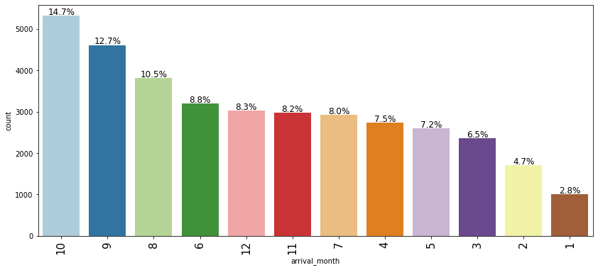

```python
# checking for busiest months in hotel
labeled_barplot(hotel, 'arrival_month', perc=True)
```

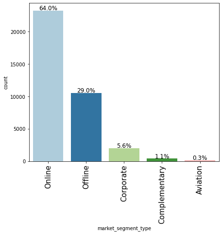

```python
# checking market segment
labeled_barplot(hotel, 'market_segment_type', perc=True)
```

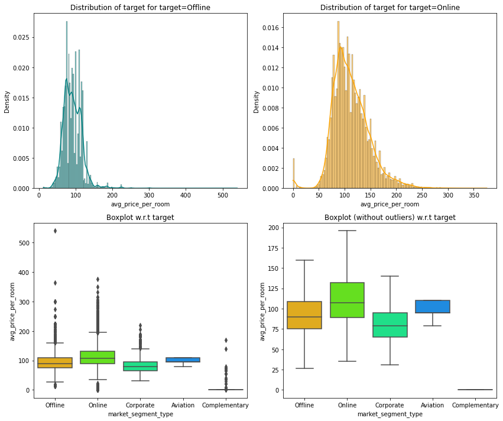

```python
# checking average price per room vs market segment
distribution_plot_wrt_target(hotel, 'avg_price_per_room', 'market_segment_type')
```

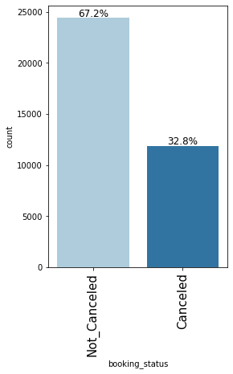

```python
# checking canceled bookings
labeled_barplot(hotel, 'booking_status', perc=True)
```

```
booking_status  Canceled  Not_Canceled    All
repeated_guest
All                11885         24390  36275
0                  11869         23476  35345
1                     16           914    930
------------------------------------------------------------------------------------------------------------------------
```

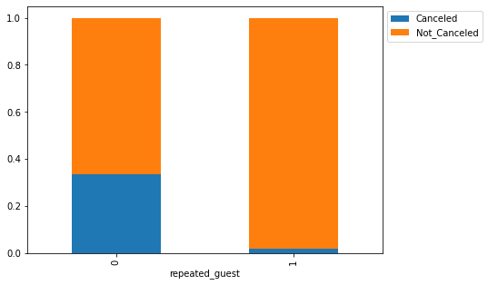

```python
# checking repeated guests vs booking status
stacked_barplot(hotel, 'repeated_guest', 'booking_status')
```

```
booking_status          Canceled  Not_Canceled    All
no_of_special_requests
All                        11885         24390  36275
0                           8545         11232  19777
1                           2703          8670  11373
2                            637          3727   4364
3                              0           675    675
4                              0            78     78
5                              0             8      8
------------------------------------------------------------------------------------------------------------------------
```

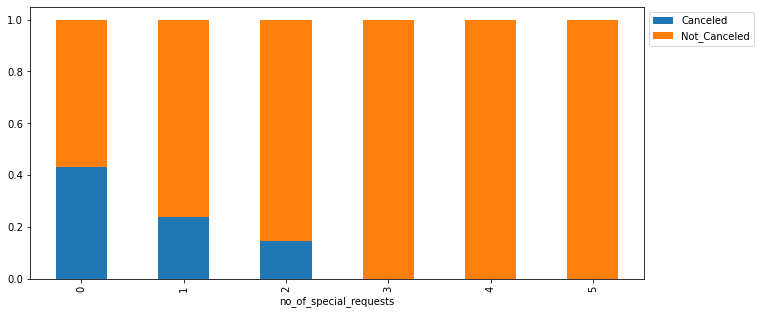

```python
# checking repeated guests vs booking status
stacked_barplot(hotel, 'no_of_special_requests', 'booking_status')
```

**Leading Questions & Answers**:

1. What are the busiest months in the hotel?
   - The top 5 busiest months in the hotel are:
     - October (14.7%)
     - September (12.7%)
     - August (10.5%)
     - June (8.8%)
     - December (8.3%)
2. Which market segment do most of the guests come from?
   - Online market segment has by far the most number of guests with 64%.
   - Offline is the next highest with 29%.
   - Corporate, Complementary, and Aviation make up the remaining 7% of guests.
3. Hotel rates are dynamic and change according to demand and customer demographics. What are the differences in room prices in different market segments?
   - The average room price varies by market segment.
     - Aside from Complementary, the Corporate market segment seems to have the lowest average prices per room.
     - Disregarding Complementary, the Aviation market segment has the smallest distribution of average price.
     - Online market segment has the largest distribution and the highest average room price.
       - This is odd because typically you would expect to see online rates be cheaper than offline rates.
     - Another interesting thing to note is that there are some outliers in the Complementary market segment. This is odd because if a room is complementary (free) it should not have a price associated with it. We should maybe clean this when we do data preprocessing.
4. What percentage of bookings are canceled?
   - 32.8% of bookings are canceled.
   - 67.2% of bookings are not canceled.
5. Repeating guests are the guests who stay in the hotel often and are important to brand equity. What percentage of repeating guests cancel?
   - Of the 930 guests who are repeats, 16 of them have canceled their reservation. This equates to ~1.7%
6. Many guests have special requirements when booking a hotel room. Do these requirements affect booking cancellation?
   - It seems that the larger the number of special requests that a guest has, the less likely they are to cancel.
     - ~43% of guests with 0 special requests canceled their booking (8545/19777).
     - ~24% of guests with 1 special request canceled their booking (2703/11373).
     - ~15% of guests with 2 special requests canceled their booking (637/4364).
     - 0% of guests with 3 or more special requests canceled their booking.

### Additional EDA

#### Univariate

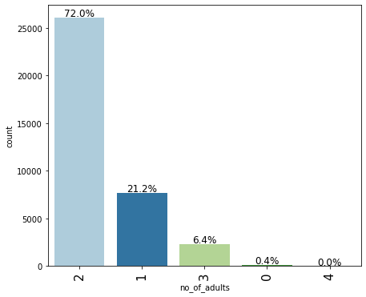

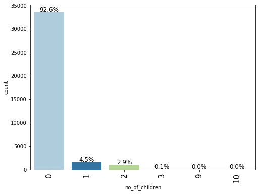

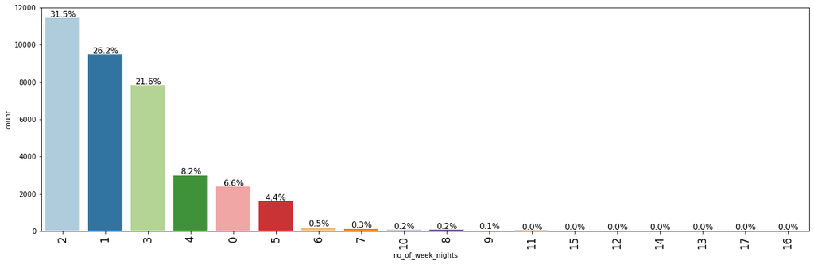

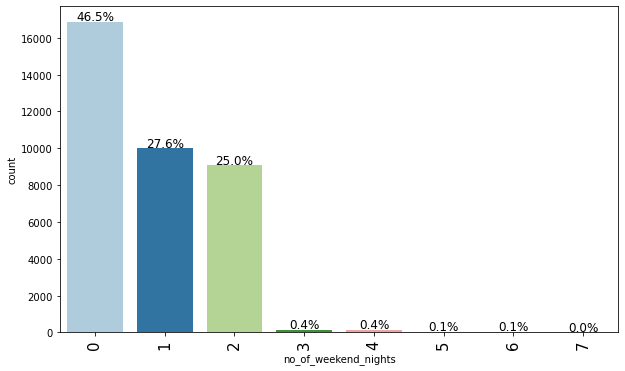

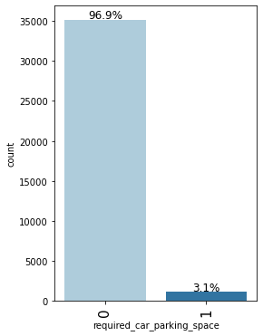

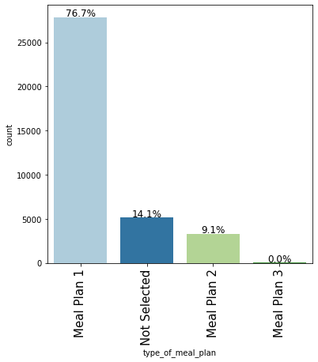

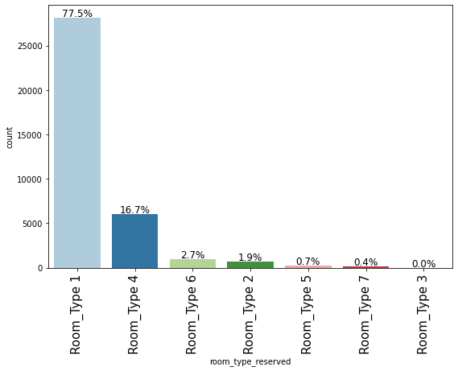

```python
# number of adults
labeled_barplot(hotel, 'no_of_adults', perc=True)

# number of children
labeled_barplot(hotel, 'no_of_children', perc=True)

# number of week nights
labeled_barplot(hotel, 'no_of_week_nights', perc=True)

# number of weekend nights
labeled_barplot(hotel, 'no_of_weekend_nights', perc=True)

# required parking
labeled_barplot(hotel, 'required_car_parking_space', perc=True)

# meal plan
labeled_barplot(hotel, 'type_of_meal_plan', perc=True)

# room type
labeled_barplot(hotel, 'room_type_reserved', perc=True)
```

#### Observations:

- 72% of bookings have 2 adults, 21.2% have 1 adult, and 6.4% have 3 adults.
  - 0.4% of bookings have 0 adults. This could be an anamoly or data entry error as children typically aren't allowed to book a hotel room without an adult.
- Overwhelming majority (92.6%) of bookings have 0 children present.
- Top 5 number of weeknights for bookings:
  1. 2 at 31.5%
  2. 1 at 26.2%
  3. 3 at 21.6%
  4. 4 at 8.2%
  5. 0 at 6.6%
- Top 3 number of weekend nights for bookings:
  1. 0 at 46.5%
  2. 1 at 27.6%
  3. 2 at 25%
- Overwhelming majority (96.9%) of guests did not require a parking space with their booking.
- Meal plan 1 was the most popular choice among guests at 76.7%. On the other hand, almost 0% of the guests chose meal plan 3.
- Room type 1 was the most popular type in the bookings at 77.5%; room type 4 was the second most frequent at 16.7%.

#### Bivariate

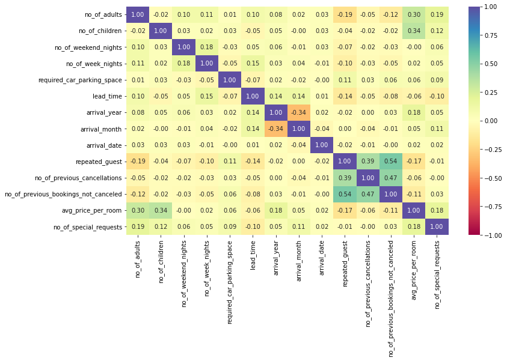

```python
# heatmap to show correlation between variables - code taken from MLS2 - Session_Notebook_Machine_Failure_Prediction.ipynb
cols_list = hotel.select_dtypes(include=np.number).columns.tolist()

plt.figure(figsize=(12, 7))
sns.heatmap(
    hotel[cols_list].corr(), annot=True, vmin=-1, vmax=1, fmt=".2f", cmap="Spectral"
)
plt.show()
```

#### Observations:

- There are a few positive correlations among the variables, but they are not very strong.
- no_of_previous_bookings_not_canceled and repeated_guest has a correlation of 0.54
  - This makes sense because a guest who did not cancel their previous booking is more likely to be a repeat guest.
- no_of_previous_bookings_not_canceled and no_of_previous_cancellations has a correlation of 0.47
  - This could be a coincidence because a relationship between these two variables does not make much sense.
- no_of_children and avg_price_per_room has a correlation of 0.34
  - We would expect to see the number of children go up as average price of room goes down because families are usually on a tighter budget, especially when traveling and on vacation.

## Data Preprocessing

### Missing Value Treatment

- There are no missing values to treat in the dataset.

### Feature Engineering

```python
# creating new dataframe with corrected complementary price
hotel_fixed = hotel.copy()
hotel_fixed.loc[hotel_fixed['market_segment_type'] == 'Complementary', 'avg_price_per_room'] = 0

# converting booking status
hotel_fixed['booking_status'] = hotel_fixed['booking_status'].apply(lambda x: 1 if x == 'Canceled' else 0)
```

### Outlier Detection

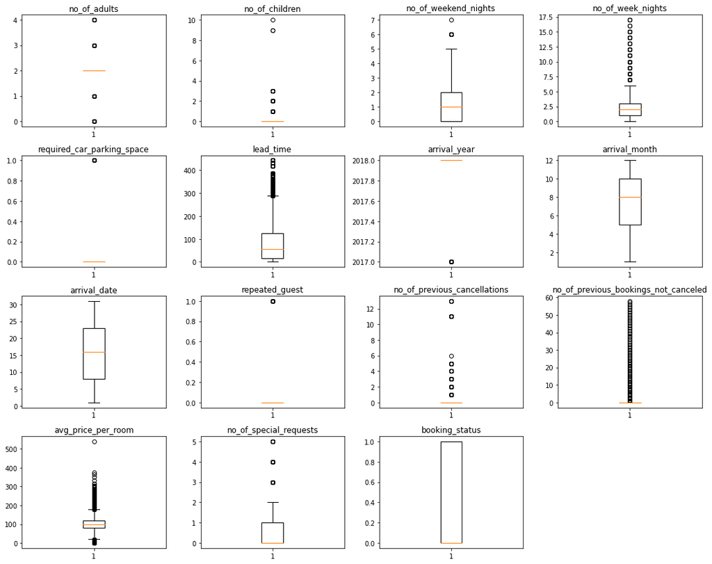

```python
# outlier detection using boxplot - taken from MLS2 - Session_Notebook_Machine_Failure_Prediction.ipynb
numeric_columns = hotel_fixed.select_dtypes(include=np.number).columns.tolist()

plt.figure(figsize=(15, 12))

for i, variable in enumerate(numeric_columns):
    plt.subplot(4, 4, i + 1)
    plt.boxplot(hotel_fixed[variable], whis=1.5)
    plt.tight_layout()
    plt.title(variable)

plt.show()
```

- There are outliers in the data, but we will leave them as is since they are proper values.

### Data Preparation

```python
# specifying independent and dependent variables
X = hotel_fixed.drop(['booking_status'], axis=1)
Y = hotel_fixed['booking_status']

# adding a constant to the independent variables
X = sm.add_constant(X)

# creating dummy X variables
X = pd.get_dummies(X, drop_first=True)

# Splitting data in train and test sets
X_train, X_test, y_train, y_test = train_test_split(X, Y, test_size=0.3, random_state=1)
```

```python
# comparing distribution of independent variable values in train vs test model
print("Shape of Training set : ", X_train.shape)
print("Shape of test set : ", X_test.shape)
print("Percentage of classes in training set:")
print(y_train.value_counts(normalize=True))
print("Percentage of classes in test set:")
print(y_test.value_counts(normalize=True))
```

```
Shape of Training set :  (25392, 28)
Shape of test set :  (10883, 28)
Percentage of classes in training set:
0   0.67064
1   0.32936
Name: booking_status, dtype: float64
Percentage of classes in test set:
0   0.67638
1   0.32362
Name: booking_status, dtype: float64
```

- The distribution of values between "canceled" and "not canceled" is very close between the test and training set.

## EDA

- It is a good idea to explore the data once again after manipulating it.

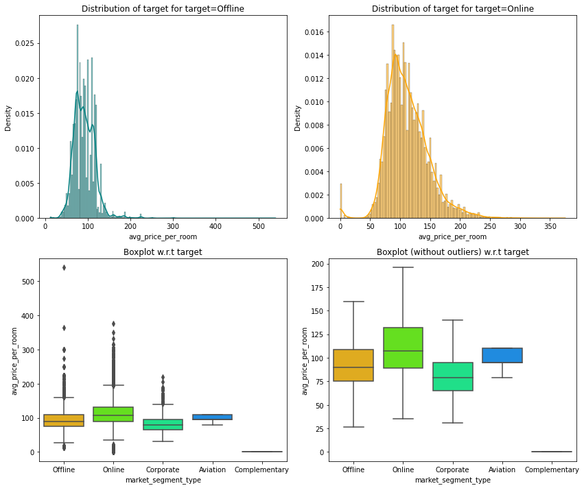

```python
# checking average price per room vs market segment again since we made the avg price for complementary segment all 0
distribution_plot_wrt_target(hotel_fixed, 'avg_price_per_room', 'market_segment_type')
```

```python
# checking the sum of avg price for the complementary market segment to make sure it is 0
hotel_fixed.loc[hotel_fixed['market_segment_type'] == 'Complementary', 'avg_price_per_room'].sum()
```

```
0.0
```

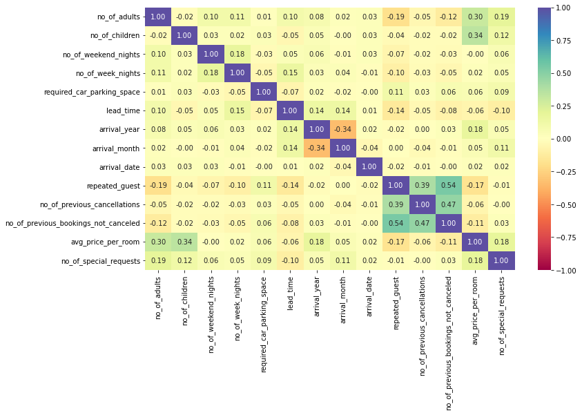

```python
# heatmap to show correlation between variables - code taken from MLS2 - Session_Notebook_Machine_Failure_Prediction.ipynb
cols_list = hotel_fixed.select_dtypes(include=np.number).columns.tolist()

plt.figure(figsize=(12, 7))
sns.heatmap(
    hotel[cols_list].corr(), annot=True, vmin=-1, vmax=1, fmt=".2f", cmap="Spectral"
)
plt.show()
```

```python
hotel_fixed.info()
```

```
<class 'pandas.core.frame.DataFrame'>
RangeIndex: 36275 entries, 0 to 36274
Data columns (total 18 columns):
 #   Column                                Non-Null Count  Dtype
---  ------                                --------------  -----
 0   no_of_adults                          36275 non-null  int64
 1   no_of_children                        36275 non-null  int64
 2   no_of_weekend_nights                  36275 non-null  int64
 3   no_of_week_nights                     36275 non-null  int64
 4   type_of_meal_plan                     36275 non-null  object
 5   required_car_parking_space            36275 non-null  int64
 6   room_type_reserved                    36275 non-null  object
 7   lead_time                             36275 non-null  int64
 8   arrival_year                          36275 non-null  int64
 9   arrival_month                         36275 non-null  int64
 10  arrival_date                          36275 non-null  int64
 11  market_segment_type                   36275 non-null  object
 12  repeated_guest                        36275 non-null  int64
 13  no_of_previous_cancellations          36275 non-null  int64
 14  no_of_previous_bookings_not_canceled  36275 non-null  int64
 15  avg_price_per_room                    36275 non-null  float64
 16  no_of_special_requests                36275 non-null  int64
 17  booking_status                        36275 non-null  int64
dtypes: float64(1), int64(14), object(3)
memory usage: 5.0+ MB
```

#### Observations:

- The distributions looks much better. Before, there were outliers on the complmenetary market segment which does not make sense as these rooms would be free.
- The average price per room for the "Complementary" market segment is now 0 as it should be.
- No change in the heatmap, so the correlation between variables stayed the same after the data transformations.
- There are 3 categorical variables that will be transformed into dummy variables for the modeling.
  - type of meal plan
  - room_type_reserved
  - market_segment_type

## Building a Logistic Regression model

```python
# fitting logistic regression model
logit = sm.Logit(y_train, X_train.astype(float))
lg = logit.fit(disp=False)

print(lg.summary())
```

```
                           Logit Regression Results
==============================================================================
Dep. Variable:         booking_status   No. Observations:                25392
Model:                          Logit   Df Residuals:                    25364
Method:                           MLE   Df Model:                           27
Date:                Thu, 07 Jul 2022   Pseudo R-squ.:                  0.3293
Time:                        17:37:13   Log-Likelihood:                -10793.
converged:                      False   LL-Null:                       -16091.
Covariance Type:            nonrobust   LLR p-value:                     0.000
========================================================================================================
                                           coef    std err          z      P>|z|      [0.025      0.975]
--------------------------------------------------------------------------------------------------------
const                                 -924.5900    120.817     -7.653      0.000   -1161.387    -687.793
no_of_adults                             0.1135      0.038      3.017      0.003       0.040       0.187
no_of_children                           0.1563      0.057      2.732      0.006       0.044       0.268
no_of_weekend_nights                     0.1068      0.020      5.398      0.000       0.068       0.146
no_of_week_nights                        0.0398      0.012      3.239      0.001       0.016       0.064
required_car_parking_space              -1.5939      0.138    -11.561      0.000      -1.864      -1.324
lead_time                                0.0157      0.000     58.868      0.000       0.015       0.016
arrival_year                             0.4570      0.060      7.633      0.000       0.340       0.574
arrival_month                           -0.0415      0.006     -6.418      0.000      -0.054      -0.029
arrival_date                             0.0005      0.002      0.252      0.801      -0.003       0.004
repeated_guest                          -2.3469      0.617     -3.805      0.000      -3.556      -1.138
no_of_previous_cancellations             0.2664      0.086      3.108      0.002       0.098       0.434
no_of_previous_bookings_not_canceled    -0.1727      0.153     -1.131      0.258      -0.472       0.127
avg_price_per_room                       0.0188      0.001     25.404      0.000       0.017       0.020
no_of_special_requests                  -1.4690      0.030    -48.790      0.000      -1.528      -1.410
type_of_meal_plan_Meal Plan 2            0.1768      0.067      2.654      0.008       0.046       0.307
type_of_meal_plan_Meal Plan 3            8.3488     38.379      0.218      0.828     -66.872      83.570
type_of_meal_plan_Not Selected           0.2782      0.053      5.245      0.000       0.174       0.382
room_type_reserved_Room_Type 2          -0.3610      0.131     -2.761      0.006      -0.617      -0.105
room_type_reserved_Room_Type 3          -0.0009      1.310     -0.001      0.999      -2.569       2.567
room_type_reserved_Room_Type 4          -0.2821      0.053     -5.305      0.000      -0.386      -0.178
room_type_reserved_Room_Type 5          -0.7176      0.209     -3.432      0.001      -1.127      -0.308
room_type_reserved_Room_Type 6          -0.9456      0.147     -6.434      0.000      -1.234      -0.658
room_type_reserved_Room_Type 7          -1.3964      0.293     -4.767      0.000      -1.971      -0.822
market_segment_type_Complementary      -12.5090     44.651     -0.280      0.779    -100.024      75.006
market_segment_type_Corporate           -1.1935      0.266     -4.487      0.000      -1.715      -0.672
market_segment_type_Offline             -2.1955      0.255     -8.625      0.000      -2.694      -1.697
market_segment_type_Online              -0.3990      0.251     -1.588      0.112      -0.891       0.093
========================================================================================================
```

```python
# taken from MLS1 - IncomeGroupClassification_CaseStudy_DSBA.ipynb

# defining a function to compute different metrics to check performance of a classification model built using statsmodels
def model_performance_classification_statsmodels(
    model, predictors, target, threshold=0.5
):
    """
    Function to compute different metrics to check classification model performance

    model: classifier
    predictors: independent variables
    target: dependent variable
    threshold: threshold for classifying the observation as class 1
    """

    # checking which probabilities are greater than threshold
    pred_temp = model.predict(predictors) > threshold
    # rounding off the above values to get classes
    pred = np.round(pred_temp)

    acc = accuracy_score(target, pred)  # to compute Accuracy
    recall = recall_score(target, pred)  # to compute Recall
    precision = precision_score(target, pred)  # to compute Precision
    f1 = f1_score(target, pred)  # to compute F1-score

    # creating a dataframe of metrics
    df_perf = pd.DataFrame(
        {"Accuracy": acc, "Recall": recall, "Precision": precision, "F1": f1,},
        index=[0],
    )

    return df_perf

# defining a function to plot the confusion_matrix of a classification model


def confusion_matrix_statsmodels(model, predictors, target, threshold=0.5):
    """
    To plot the confusion_matrix with percentages

    model: classifier
    predictors: independent variables
    target: dependent variable
    threshold: threshold for classifying the observation as class 1
    """
    y_pred = model.predict(predictors) > threshold
    cm = confusion_matrix(target, y_pred)
    labels = np.asarray(
        [
            ["{0:0.0f}".format(item) + "\n{0:.2%}".format(item / cm.flatten().sum())]
            for item in cm.flatten()
        ]
    ).reshape(2, 2)

    plt.figure(figsize=(6, 4))
    sns.heatmap(cm, annot=labels, fmt="")
    plt.ylabel("True label")
    plt.xlabel("Predicted label")
```

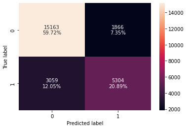

```python
# confusion matrix for training
confusion_matrix_statsmodels(lg, X_train, y_train)
```

```python
# printing out the training performance
print('Training performance:')
model_performance_classification_statsmodels(lg, X_train, y_train)
```

```
Training performance:
```

|  | Accuracy | Recall | Precision | F1 |
| --- | --- | --- | --- | --- |
| 0 | 0.80604 | 0.63422 | 0.73975 | 0.68293 |

#### Observations:

- The F1 score of the initial model is 0.68 - we will try to increase this with subsequent models.
- There are quite a few variables with negative coeffecients, meaning the probability of a booking resulting in cancellation decreases with the increase of the correpsonding attribute value.
- There are quite a few variables whose p-value is greater than 0.05. These may need to be dropped but first we will have to check for multicollinearity.

## Checking Multicollinearity

- In order to make statistical inferences from a logistic regression model, it is important to ensure that there is no multicollinearity present in the data.

```python
# we will define a function to check VIF
def checking_vif(predictors):
    vif = pd.DataFrame()
    vif["feature"] = predictors.columns

    # calculating VIF for each feature
    vif["VIF"] = [
        variance_inflation_factor(predictors.values, i)
        for i in range(len(predictors.columns))
    ]
    return vif

# checking VIF values against X_train
checking_vif(X_train)
```

|  | feature | VIF |
| --- | --- | --- |
| 0 | const | 39473094.68400 |
| 1 | no_of_adults | 1.34843 |
| 2 | no_of_children | 1.97789 |
| 3 | no_of_weekend_nights | 1.06954 |
| 4 | no_of_week_nights | 1.09572 |
| 5 | required_car_parking_space | 1.03985 |
| 6 | lead_time | 1.39511 |
| 7 | arrival_year | 1.43101 |
| 8 | arrival_month | 1.27576 |
| 9 | arrival_date | 1.00674 |
| 10 | repeated_guest | 1.78340 |
| 11 | no_of_previous_cancellations | 1.39569 |
| 12 | no_of_previous_bookings_not_canceled | 1.65192 |
| 13 | avg_price_per_room | 2.06431 |
| 14 | no_of_special_requests | 1.24733 |
| 15 | type_of_meal_plan_Meal Plan 2 | 1.27225 |
| 16 | type_of_meal_plan_Meal Plan 3 | 1.02520 |
| 17 | type_of_meal_plan_Not Selected | 1.27227 |
| 18 | room_type_reserved_Room_Type 2 | 1.10135 |
| 19 | room_type_reserved_Room_Type 3 | 1.00331 |
| 20 | room_type_reserved_Room_Type 4 | 1.36190 |
| 21 | room_type_reserved_Room_Type 5 | 1.02756 |
| 22 | room_type_reserved_Room_Type 6 | 1.97443 |
| 23 | room_type_reserved_Room_Type 7 | 1.11590 |
| 24 | market_segment_type_Complementary | 4.51087 |
| 25 | market_segment_type_Corporate | 16.92852 |
| 26 | market_segment_type_Offline | 64.11397 |
| 27 | market_segment_type_Online | 71.17644 |

- There are 3 variables with VIF higher than 5 but these are dummy variables so we can disregard them.
- Next, we will look at dropping the high p-values.

```python
# initial list of columns
cols = X_train.columns.tolist()

# setting an initial max p-value
max_p_value = 1

while len(cols) > 0:
    # defining the train set
    x_train_aux = X_train[cols]

    # fitting the model
    model = sm.Logit(y_train, x_train_aux).fit(disp=False)

    # getting the p-values and the maximum p-value
    p_values = model.pvalues
    max_p_value = max(p_values)

    # name of the variable with maximum p-value
    feature_with_p_max = p_values.idxmax()

    if max_p_value > 0.05:
        cols.remove(feature_with_p_max)
    else:
        break

selected_features = cols
print(selected_features)
```

[output not shown]

```python
# new dataframes for selected features
X_train1 = X_train[selected_features]
X_test1 = X_test[selected_features]
```

```python
# new model using the selected features
logit1 = sm.Logit(y_train, X_train1.astype(float))
lg1 = logit1.fit(disp=False)
print(lg1.summary())
```

```
                           Logit Regression Results
==============================================================================
Dep. Variable:         booking_status   No. Observations:                25392
Model:                          Logit   Df Residuals:                    25370
Method:                           MLE   Df Model:                           21
Date:                Thu, 07 Jul 2022   Pseudo R-squ.:                  0.3284
Time:                        17:37:15   Log-Likelihood:                -10807.
converged:                       True   LL-Null:                       -16091.
Covariance Type:            nonrobust   LLR p-value:                     0.000
==================================================================================================
                                     coef    std err          z      P>|z|      [0.025      0.975]
--------------------------------------------------------------------------------------------------
const                           -914.6802    120.483     -7.592      0.000   -1150.823    -678.538
no_of_adults                       0.1076      0.037      2.886      0.004       0.035       0.181
no_of_children                     0.1521      0.057      2.657      0.008       0.040       0.264
no_of_weekend_nights               0.1086      0.020      5.500      0.000       0.070       0.147
no_of_week_nights                  0.0417      0.012      3.398      0.001       0.018       0.066
required_car_parking_space        -1.5948      0.138    -11.564      0.000      -1.865      -1.324
lead_time                          0.0157      0.000     59.219      0.000       0.015       0.016
arrival_year                       0.4518      0.060      7.567      0.000       0.335       0.569
arrival_month                     -0.0424      0.006     -6.569      0.000      -0.055      -0.030
repeated_guest                    -2.7359      0.557     -4.913      0.000      -3.827      -1.644
no_of_previous_cancellations       0.2288      0.077      2.982      0.003       0.078       0.379
avg_price_per_room                 0.0192      0.001     26.376      0.000       0.018       0.021
no_of_special_requests            -1.4703      0.030    -48.899      0.000      -1.529      -1.411
type_of_meal_plan_Meal Plan 2      0.1646      0.067      2.475      0.013       0.034       0.295
type_of_meal_plan_Not Selected     0.2855      0.053      5.398      0.000       0.182       0.389
room_type_reserved_Room_Type 2    -0.3566      0.131     -2.729      0.006      -0.613      -0.101
room_type_reserved_Room_Type 4    -0.2832      0.053     -5.340      0.000      -0.387      -0.179
room_type_reserved_Room_Type 5    -0.7348      0.208     -3.526      0.000      -1.143      -0.326
room_type_reserved_Room_Type 6    -0.9672      0.147     -6.586      0.000      -1.255      -0.679
room_type_reserved_Room_Type 7    -1.4334      0.293     -4.900      0.000      -2.007      -0.860
market_segment_type_Corporate     -0.7941      0.103     -7.724      0.000      -0.996      -0.593
market_segment_type_Offline       -1.7875      0.052    -34.402      0.000      -1.889      -1.686
==================================================================================================
```

#### Observations:

- Initially, there appeared to be high multicollinearity in some of the VIF values but these were dummy variables.
- After dropping out these variables, the p-values are all <0.05. This suggests that removing these variables has resulted in successful elimination of multicollinearity.
  - arrival_date
  - no_of_previous_bookings_not_canceled
  - type_of_meal_plan_Meal Plan 3
  - room_type_reserved_Room_Type 3
  - market_segment_type_Complementary
  - market_segment_type_Online

## Model performance evaluation

### Checking Training Performance

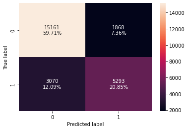

```python
# confusion matrix
confusion_matrix_statsmodels(lg1, X_train1, y_train)
```

```python
# checking the metrics for training set
print('Training performance model:')
log_reg_model_train_perf = model_performance_classification_statsmodels(lg1, X_train1, y_train)
log_reg_model_train_perf
```

```
Training performance model:
```

|  | Accuracy | Recall | Precision | F1 |
| --- | --- | --- | --- | --- |
| 0 | 0.80553 | 0.63291 | 0.73914 | 0.68191 |

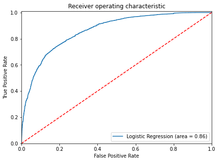

```python
# ROC-AUC on training set; code taken from Logistic_Regression_Hands-On.ipynb
logit_roc_auc_train = roc_auc_score(y_train, lg1.predict(X_train1))
fpr, tpr, thresholds = roc_curve(y_train, lg1.predict(X_train1))
plt.figure(figsize=(7, 5))
plt.plot(fpr, tpr, label="Logistic Regression (area = %0.2f)" % logit_roc_auc_train)
plt.plot([0, 1], [0, 1], "r--")
plt.xlim([0.0, 1.0])
plt.ylim([0.0, 1.01])
plt.xlabel("False Positive Rate")
plt.ylabel("True Positive Rate")
plt.title("Receiver operating characteristic")
plt.legend(loc="lower right")
plt.show()
```

#### Finding Optimal Threshold

```python
# Optimal threshold as per AUC-ROC curve
# The optimal cut off would be where tpr is high and fpr is low
fpr, tpr, thresholds = roc_curve(y_train, lg1.predict(X_train1))

optimal_idx = np.argmax(tpr - fpr)
optimal_threshold_auc_roc = thresholds[optimal_idx]
print(optimal_threshold_auc_roc)
```

```
0.36971462864141086
```

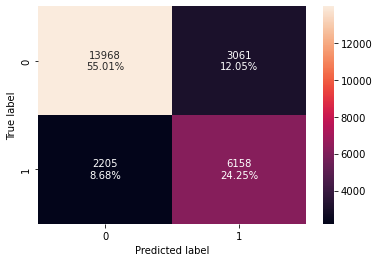

```python
# confusion matrix using optimal threshold
confusion_matrix_statsmodels(
    lg1, X_train1, y_train, threshold=optimal_threshold_auc_roc
)
```

```python
# checking performance using optimal threshold
log_reg_model_train_perf_threshold_auc_roc = model_performance_classification_statsmodels(
    lg1, X_train1, y_train, threshold=optimal_threshold_auc_roc
)
print('Training performance with optimal threshold:')
log_reg_model_train_perf_threshold_auc_roc
```

```
Training performance with optimal threshold:
```

|  | Accuracy | Recall | Precision | F1 |
| --- | --- | --- | --- | --- |
| 0 | 0.79261 | 0.73634 | 0.66797 | 0.70049 |

#### Observations:

- Accuracy is very close between the initial training performance and training performance using optimal threshold at roughly 0.80.
- Recall using the optimal threshold is higher than on the initial training performance at 0.73 (optimal) vs 0.63 (initial).
- Precision using the optimal threshold is lower than on the initial training performance at 0.67 (optimal) vs 0.74 (initial).
- F1 score improved from 0.68 (initial) to 0.70 (optimal).
- We should use a precision-recall curve to see if there is a better threshold.

#### Precision-Recall Curve

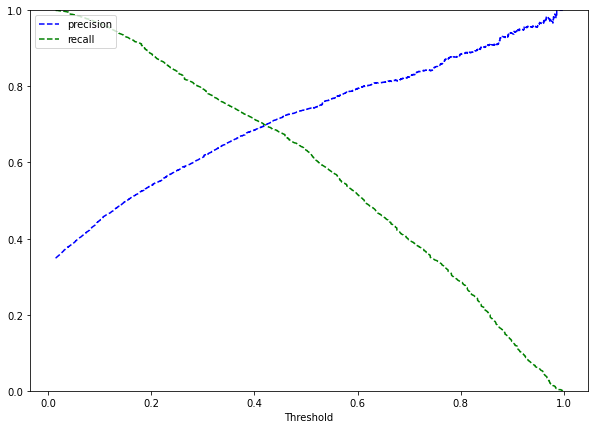

```python
y_scores = lg1.predict(X_train1)
prec, rec, tre = precision_recall_curve(y_train, y_scores,)


def plot_prec_recall_vs_tresh(precisions, recalls, thresholds):
    plt.plot(thresholds, precisions[:-1], "b--", label="precision")
    plt.plot(thresholds, recalls[:-1], "g--", label="recall")
    plt.xlabel("Threshold")
    plt.legend(loc="upper left")
    plt.ylim([0, 1])


plt.figure(figsize=(10, 7))
plot_prec_recall_vs_tresh(prec, rec, tre)
plt.show()
```

- It appears that the intersection of the precision and recall lines is slightly larger than 0.4 so we will try 0.41 as an alternate threshold.

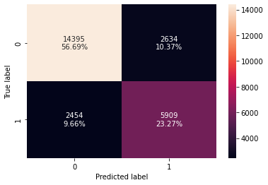

```python
# setting the alternate threshold
alt_threshold_curve = 0.41

# checking confusion matrix
confusion_matrix_statsmodels(
    lg1, X_train1, y_train, threshold=alt_threshold_curve
)
```

```python
# checking model performance for alt threshold
log_reg_model_train_perf_alt_threshold = model_performance_classification_statsmodels(
    lg1, X_train1, y_train, threshold=alt_threshold_curve
)
print('Training performance with alternate threshold:')
log_reg_model_train_perf_alt_threshold
```

```
Training performance with alternate threshold:
```

|  | Accuracy | Recall | Precision | F1 |
| --- | --- | --- | --- | --- |
| 0 | 0.79962 | 0.70656 | 0.69168 | 0.69904 |

#### Observations:

- Accuracy is very close between the training performance using the alternate threshold and training performance using optimal threshold at roughly 0.80.
- Recall using the optimal threshold is higher than on the alternate threshold at 0.73 (optimal) vs 0.70 (alternate).
- Precision using the optimal threshold is slightly lower than on the alternate threshold at 0.67 (optimal) vs 0.69 (alternate).
- F1 score is rougly the same on the optimal vs alternate thresholds at 0.70.

### Checking Test Performance

#### Default Threshold

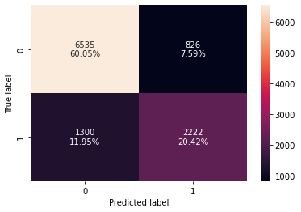

```python
# creating confusion matrix
confusion_matrix_statsmodels(lg1, X_test1, y_test)
```

```python
# test performance
log_reg_model_test_perf = model_performance_classification_statsmodels(lg1, X_test1, y_test)

print('Test performance:')
log_reg_model_test_perf
```

```
Test performance:
```

|  | Accuracy | Recall | Precision | F1 |
| --- | --- | --- | --- | --- |
| 0 | 0.80465 | 0.63089 | 0.72900 | 0.67641 |

#### Using Optimal Threshold (0.37)

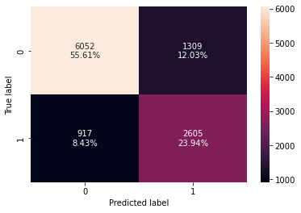

```python
# confusion matrix using optimal threshold
confusion_matrix_statsmodels(
    lg1, X_test1, y_test, threshold=optimal_threshold_auc_roc
)
```

```python
# checking performance using optimal threshold
log_reg_model_test_perf_threshold_auc_roc = model_performance_classification_statsmodels(
    lg1, X_train1, y_train, threshold=optimal_threshold_auc_roc
)
print('Test performance with optimal threshold:')
log_reg_model_test_perf_threshold_auc_roc
```

```
Test performance with optimal threshold:
```

[output not shown]

#### Using Alternate Threshold (0.41)

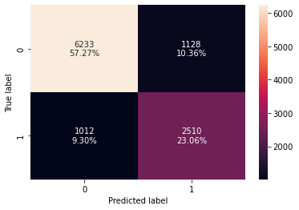

```python
# checking confusion matrix
confusion_matrix_statsmodels(
    lg1, X_test1, y_test, threshold=alt_threshold_curve
)
```

```python
# checking model performance for alt threshold
log_reg_model_test_perf_alt_threshold = model_performance_classification_statsmodels(
    lg1, X_test1, y_test, threshold=alt_threshold_curve
)
print('Training performance with alternate threshold:')
log_reg_model_test_perf_alt_threshold
```

```
Training performance with alternate threshold:
```

|  | Accuracy | Recall | Precision | F1 |
| --- | --- | --- | --- | --- |
| 0 | 0.80336 | 0.71266 | 0.68994 | 0.70112 |

#### Performance Summary

```python
# comparing training performance
models_train_comp_df = pd.concat(
    [
        log_reg_model_train_perf.T,
        log_reg_model_train_perf_threshold_auc_roc.T,
        log_reg_model_train_perf_alt_threshold.T,
    ],
    axis=1,
)
models_train_comp_df.columns = [
    'default',
    '0.37',
    '0.41',
]

print('Training performance comparison:')
models_train_comp_df
```

```
Training performance comparison:
```

|  | default | 0.37 | 0.41 |
| --- | --- | --- | --- |
| Accuracy | 0.80553 | 0.79261 | 0.79962 |
| Recall | 0.63291 | 0.73634 | 0.70656 |
| Precision | 0.73914 | 0.66797 | 0.69168 |
| F1 | 0.68191 | 0.70049 | 0.69904 |

```python
# comparing test performance
models_test_comp_df = pd.concat(
    [
        log_reg_model_test_perf.T,
        log_reg_model_test_perf_threshold_auc_roc.T,
        log_reg_model_test_perf_alt_threshold.T,
    ],
    axis=1,
)
models_test_comp_df.columns = [
    'default',
    '0.37',
    '0.41',
]

print('Test performance comparison:')
models_train_comp_df
```

```
Test performance comparison:
```

[output not shown]

## Final Model Summary

```python
# printing summary of final model again
print(lg1.summary())
```

```
                           Logit Regression Results
==============================================================================
Dep. Variable:         booking_status   No. Observations:                25392
Model:                          Logit   Df Residuals:                    25370
Method:                           MLE   Df Model:                           21
Date:                Thu, 07 Jul 2022   Pseudo R-squ.:                  0.3284
Time:                        17:37:17   Log-Likelihood:                -10807.
converged:                       True   LL-Null:                       -16091.
Covariance Type:            nonrobust   LLR p-value:                     0.000
==================================================================================================
                                     coef    std err          z      P>|z|      [0.025      0.975]
--------------------------------------------------------------------------------------------------
const                           -914.6802    120.483     -7.592      0.000   -1150.823    -678.538
no_of_adults                       0.1076      0.037      2.886      0.004       0.035       0.181
no_of_children                     0.1521      0.057      2.657      0.008       0.040       0.264
no_of_weekend_nights               0.1086      0.020      5.500      0.000       0.070       0.147
no_of_week_nights                  0.0417      0.012      3.398      0.001       0.018       0.066
required_car_parking_space        -1.5948      0.138    -11.564      0.000      -1.865      -1.324
lead_time                          0.0157      0.000     59.219      0.000       0.015       0.016
arrival_year                       0.4518      0.060      7.567      0.000       0.335       0.569
arrival_month                     -0.0424      0.006     -6.569      0.000      -0.055      -0.030
repeated_guest                    -2.7359      0.557     -4.913      0.000      -3.827      -1.644
no_of_previous_cancellations       0.2288      0.077      2.982      0.003       0.078       0.379
avg_price_per_room                 0.0192      0.001     26.376      0.000       0.018       0.021
no_of_special_requests            -1.4703      0.030    -48.899      0.000      -1.529      -1.411
type_of_meal_plan_Meal Plan 2      0.1646      0.067      2.475      0.013       0.034       0.295
type_of_meal_plan_Not Selected     0.2855      0.053      5.398      0.000       0.182       0.389
room_type_reserved_Room_Type 2    -0.3566      0.131     -2.729      0.006      -0.613      -0.101
room_type_reserved_Room_Type 4    -0.2832      0.053     -5.340      0.000      -0.387      -0.179
room_type_reserved_Room_Type 5    -0.7348      0.208     -3.526      0.000      -1.143      -0.326
room_type_reserved_Room_Type 6    -0.9672      0.147     -6.586      0.000      -1.255      -0.679
room_type_reserved_Room_Type 7    -1.4334      0.293     -4.900      0.000      -2.007      -0.860
market_segment_type_Corporate     -0.7941      0.103     -7.724      0.000      -0.996      -0.593
market_segment_type_Offline       -1.7875      0.052    -34.402      0.000      -1.889      -1.686
==================================================================================================
```

#### Converting Coefficients

```python
# converting coefficients to odds
odds = np.exp(lg1.params)

# finding the percentage change
perc_change_odds = (np.exp(lg1.params) - 1) * 100

# removing limit from number of columns to display
pd.set_option("display.max_columns", None)

# adding the odds to a dataframe
pd.DataFrame({"Odds": odds, "Change_odd%": perc_change_odds}, index=X_train1.columns)
```

|  | Odds | Change_odd% |
| --- | --- | --- |
| const | 0.00000 | -100.00000 |
| no_of_adults | 1.11365 | 11.36527 |
| no_of_children | 1.16426 | 16.42614 |
| no_of_weekend_nights | 1.11473 | 11.47344 |
| no_of_week_nights | 1.04258 | 4.25759 |
| required_car_parking_space | 0.20296 | -79.70428 |
| lead_time | 1.01584 | 1.58364 |
| arrival_year | 1.57121 | 57.12052 |
| arrival_month | 0.95852 | -4.14835 |
| repeated_guest | 0.06483 | -93.51669 |
| no_of_previous_cancellations | 1.25712 | 25.71195 |
| avg_price_per_room | 1.01937 | 1.93716 |
| no_of_special_requests | 0.22986 | -77.01430 |
| type_of_meal_plan_Meal Plan 2 | 1.17897 | 17.89735 |
| type_of_meal_plan_Not Selected | 1.33037 | 33.03695 |
| room_type_reserved_Room_Type 2 | 0.70002 | -29.99804 |
| room_type_reserved_Room_Type 4 | 0.75339 | -24.66064 |
| room_type_reserved_Room_Type 5 | 0.47959 | -52.04080 |
| room_type_reserved_Room_Type 6 | 0.38016 | -61.98385 |
| room_type_reserved_Room_Type 7 | 0.23849 | -76.15129 |
| market_segment_type_Corporate | 0.45198 | -54.80215 |
| market_segment_type_Offline | 0.16737 | -83.26270 |

#### Coefficient Interpretations:

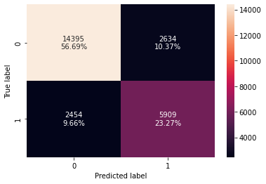

```python
# confusion matrix for final model train set
confusion_matrix_statsmodels(
    lg1, X_train1, y_train, threshold=alt_threshold_curve
)
```

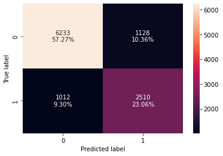

```python
# confusion matrix for final model test set
confusion_matrix_statsmodels(
    lg1, X_test1, y_test, threshold=alt_threshold_curve
)
```

```python
# building dataframe for train/test comparison
test_train_compare = pd.concat(
    [
        log_reg_model_train_perf_alt_threshold.T,
        log_reg_model_test_perf_alt_threshold.T
    ],
    axis=1,
)
test_train_compare.columns = [
    'train',
    'test'
]

# printing out comparison
print('Train vs test comparison:')
test_train_compare
```

```
Train vs test comparison:
```

|  | train | test |
| --- | --- | --- |
| Accuracy | 0.79962 | 0.80336 |
| Recall | 0.70656 | 0.71266 |
| Precision | 0.69168 | 0.68994 |
| F1 | 0.69904 | 0.70112 |

## Building a Decision Tree model

```python
# we will create new variables for the decision tree
X_tree = hotel_fixed.drop('booking_status', axis=1)
Y_tree = hotel_fixed['booking_status']

# dummy variable creation
X_tree = pd.get_dummies(X_tree, drop_first=True)

# splitting into train/test sets
X_train_t, X_test_t, y_train_t, y_test_t = train_test_split(
    X_tree, Y_tree, test_size=0.30, random_state=1
)
```

```python
# functions below taken from MLS2 - Session_Notebook_Machine_Failure_Prediction.ipynb

# defining a function to compute different metrics to check performance of a classification model built using sklearn
def model_performance_classification_sklearn(model, predictors, target):
    """
    Function to compute different metrics to check classification model performance

    model: classifier
    predictors: independent variables
    target: dependent variable
    """

    # predicting using the independent variables
    pred = model.predict(predictors)

    acc = accuracy_score(target, pred)  # to compute Accuracy
    recall = recall_score(target, pred)  # to compute Recall
    precision = precision_score(target, pred)  # to compute Precision
    f1 = f1_score(target, pred)  # to compute F1-score

    # creating a dataframe of metrics
    df_perf = pd.DataFrame(
        {"Accuracy": acc, "Recall": recall, "Precision": precision, "F1": f1,},
        index=[0],
    )

    return df_perf

def confusion_matrix_sklearn(model, predictors, target):
    """
    To plot the confusion_matrix with percentages

    model: classifier
    predictors: independent variables
    target: dependent variable
    """
    y_pred = model.predict(predictors)
    cm = confusion_matrix(target, y_pred)
    labels = np.asarray(
        [
            ["{0:0.0f}".format(item) + "\n{0:.2%}".format(item / cm.flatten().sum())]
            for item in cm.flatten()
        ]
    ).reshape(2, 2)

    plt.figure(figsize=(6, 4))
    sns.heatmap(cm, annot=labels, fmt="")
    plt.ylabel("True label")
    plt.xlabel("Predicted label")
```

#### Checking Train Performance

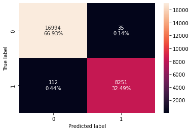

```python
# creating initial model
tree_model = DecisionTreeClassifier(random_state=1)
tree_model.fit(X_train_t, y_train_t)

# confusion matrix for initial model
confusion_matrix_sklearn(tree_model, X_train_t, y_train_t)
```

```python
# checking performance on initial model
decision_tree_perf_train = model_performance_classification_sklearn(
    tree_model, X_train_t, y_train_t
)
decision_tree_perf_train
```

|  | Accuracy | Recall | Precision | F1 |
| --- | --- | --- | --- | --- |
| 0 | 0.99421 | 0.98661 | 0.99578 | 0.99117 |

- Initial model looks fairly accurate on the train data.
- Next we will check the test performance.

#### Checking Test Performance

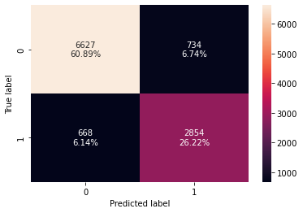

```python
# confusion matrix for initial model
confusion_matrix_sklearn(tree_model, X_test_t, y_test_t)
```

```python
# checking performance on initial model
decision_tree_perf_test = model_performance_classification_sklearn(
    tree_model, X_test_t, y_test_t
)
decision_tree_perf_test
```

|  | Accuracy | Recall | Precision | F1 |
| --- | --- | --- | --- | --- |
| 0 | 0.87118 | 0.81034 | 0.79543 | 0.80281 |

- Every metric of the test performance is significantly lower than the train performance.

#### Pre-Pruning the Tree

```python
# following code taken from MLS2 - Session_Notebook_Machine_Failure_Prediction.ipynb

# Choose the type of classifier.
estimator = DecisionTreeClassifier(random_state=1)

# Grid of parameters to choose from
parameters = {
    "class_weight": [None, "balanced"],
    "max_depth": np.arange(2, 7, 2),
    "max_leaf_nodes": [50, 75, 150, 250],
    "min_samples_split": [10, 30, 50, 70],
}

# Type of scoring used to compare parameter combinations
acc_scorer = make_scorer(f1_score)

# Run the grid search
grid_obj = GridSearchCV(estimator, parameters, scoring=acc_scorer, cv=5)
grid_obj = grid_obj.fit(X_train_t, y_train_t)

# Set the clf to the best combination of parameters
estimator = grid_obj.best_estimator_

# Fit the best algorithm to the data.
estimator.fit(X_train_t, y_train_t)
```

```
DecisionTreeClassifier(class_weight='balanced', max_depth=6, max_leaf_nodes=50,
                       min_samples_split=10, random_state=1)
```

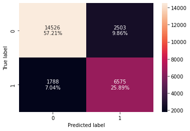

```python
# checking confusion matrix on train set
confusion_matrix_sklearn(estimator, X_train_t, y_train_t)
```

```python
# performance scores on train set
decision_tree_tune_perf_train = model_performance_classification_sklearn(
    estimator, X_train_t, y_train_t
)
print('Train performance:')
decision_tree_tune_perf_train
```

```
Train performance:
```

|  | Accuracy | Recall | Precision | F1 |
| --- | --- | --- | --- | --- |
| 0 | 0.83101 | 0.78620 | 0.72428 | 0.75397 |

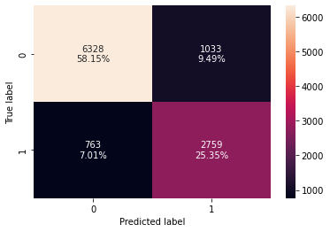

```python
# checking confusion matrix on test set
confusion_matrix_sklearn(estimator, X_test_t, y_test_t)
```

```python
# performance scores on test set
decision_tree_tune_perf_test = model_performance_classification_sklearn(
    estimator, X_test_t, y_test_t
)
print('Test performance:')
decision_tree_tune_perf_test
```

```
Test performance:
```

|  | Accuracy | Recall | Precision | F1 |
| --- | --- | --- | --- | --- |
| 0 | 0.83497 | 0.78336 | 0.72758 | 0.75444 |